# Replication of Kozlowski *et al.* “The Geometry of Culture: Analyzing the Meanings of Class through Word Embeddings”

Author

Affiliation

Hauke Licht

University of Innsbruck

Published

January 12, 2026

In their much-cited [publication](https://journals.sagepub.com/doi/full/10.1177/0003122419877135) “The Geometry of Culture: Analyzing the Meanings of Class through Word Embeddings,” Kozlowski, Taddy, and Evans show that conceptual dimensions in the embedding spaces correspond to dimensions of cultural meaning, and words’ relation with these dimensions reflects widely shared cultural associations.

## Replication: goals and approach

In this notebook, we replicate parts of their analyses. Our goal is to see if we find the same patterns they describe in their publication. We do this using their original word lists but a different word embedding model.

## Setup

```r
library(readr)
library(data.table)
library(dplyr)
library(tidyr)
library(ggplot2)

base_path <- file.path("..", "..") # NOTE only when running in quarto notebook
data_path <- file.path(base_path, "data", "replications", "kozlowski_geometry_2019")
```

**Model download**

I’m using the 200D version of Stanford NLP’s GloVe model here instead of the 50D version we used in the word embedding intro notebook. Go to script `models/download_glove_vectors.R` to download it if you don’t have it yet *or* replace `model_file <- "glove.2024.wikigiga.200d.zip"` below with `model_file <- "glove.2024.wikigiga.50d.zip"`. Note that if you choose the latter option, you’ll get different results than in the pre-compiled notebook.

```r
# Load pre-trained GloVe word embeddings
models_path <- file.path(base_path, "models")
# model_file <- "glove.2024.wikigiga.50d.zip"
model_file <- "glove.2024.wikigiga.200d.zip"
fp <- file.path(models_path, model_file)

# read the vectors from the zip file
wv <- data.table::fread(
  fp,
  skip = 1, # skip header line
  header = FALSE,
  sep = " ", # words and vector values are separated by white space
  quote = "", # no quote characters
  data.table = FALSE # return as data frame
)

# set row names to words and remove word column
row.names(wv) <- wv[[1]]
wv[[1]] <- NULL
names(wv) <- paste0("V", seq_len(ncol(wv)))
wv <- as.matrix(wv)
```

## Kozlowski *et al.* measurement strategy

#### *1. Inducing dimensions*

Kozlowski *et al.* explain that their technique for inducing cultural dimensions in the word embedding vector space builds on logic of **solving analogy tasks**:

- Adding the vector $(v_{\text{affluence}}−v_{\text{poverty}})$ to a word’s embedding is equivalent to taking one “step” in the direction of affluence.
- To tap more broadly into this latent “affluence” dimension, you can do the same computation for more polar word pairs than just (“affluence”, “poverty”), such as such as (“rich”, “poor”), (“priceless”, “worthless”), or (“prosperous”, “bankrupt”).
- Averaging the differences of several related antonym pairs then yields “a single, robust affluence dimension”.

#### *2. Computing words’ associations*

To identify the cultural associations/valence of a word, they compute the cosine similarity of its normalized vector with a given cultural dimension.

*Note:* They note that this is similar to “calculate the orthogonal projection of the word vector onto the cultural dimension of interest.”

*Example*

Say the class dimensions is constructed from the polar word pairs (“affluence”, “poverty”) , (“rich”, “poor”), (“priceless”, “worthless”), etc. Then a more positive cosine value would indicate association with affluence, and more negative values an association with poverty.

#### Summary of ingredients

1. a pre-trained word embedding
2. a set of polar word (i.e., antonym) pairs for each cultural dimension
3. a bunch of words that should be related to (“projected onto”) these dimensions

## Implementing their analyses with R

### 1. Load the antonym words pairs

I have prepared the data in their category-specific antonym word pairs lists into a long tab-separated file:

```r
fp <- file.path(data_path, "antonyms.tsv")
df <- read_tsv(fp, col_names = c("dimension", "pair"))
# split column pair into separate columns
df <- tidyr::separate(df, pair, into = c("word1", "word2"), sep = "-", remove = FALSE)
sample_n(df, 10)
```

```
# A tibble: 10 × 4
   dimension   pair                   word1      word2
   <chr>       <chr>                  <chr>      <chr>
 1 Cultivation mannered-unmannered    mannered   unmannered
 2 Affluence   luxuriant-penurious    luxuriant  penurious
 3 Morality    righteous-wicked       righteous  wicked
 4 Education   trained-untrained      trained    untrained
 5 Affluence   exorbitant-impecunious exorbitant impecunious
 6 Morality    chivalrous-knavish     chivalrous knavish
 7 Affluence   sumptuous-plain        sumptuous  plain
 8 Cultivation gracious-ungracious    gracious   ungracious
 9 Morality    virtuous-sinful        virtuous   sinful
10 Affluence   expensive-inexpensive  expensive  inexpensive
```

```r
table(df$dimension)
```

```
  Affluence Cultivation   Education  Employment      Gender    Morality
         44          25           9          20          10          27
       Race      Status
          7          15
```

### 2. Inducing a dimensions using antonym pairs

Kozlowski’s approach is to

1. span vectors between the polar terms in each word pair (by subtracting the second term’s embedding from the first one’s) , and
2. then average these ‘direction’ vectors into one vector

They do this for *each* dimension separately!

```r
unique(df$dimension)
```

```
[1] "Affluence"   "Gender"      "Race"        "Cultivation" "Employment"
[6] "Education"   "Status"      "Morality"
```

```r
# Look at first group as example
expl <- filter(df, dimension == "Affluence")
expl
```

```
# A tibble: 44 × 4
   dimension pair                   word1      word2
   <chr>     <chr>                  <chr>      <chr>
 1 Affluence rich-poor              rich       poor
 2 Affluence richer-poorer          richer     poorer
 3 Affluence richest-poorest        richest    poorest
 4 Affluence affluence-poverty      affluence  poverty
 5 Affluence affluent-destitute     affluent   destitute
 6 Affluence advantaged-needy       advantaged needy
 7 Affluence wealthy-impoverished   wealthy    impoverished
 8 Affluence costly-economical      costly     economical
 9 Affluence exorbitant-impecunious exorbitant impecunious
10 Affluence expensive-inexpensive  expensive  inexpensive
# ℹ 34 more rows
```

```r
# Helper function to get word vector
get_word_vector <- function(word) {
  if (word %in% rownames(wv)) {
    return(wv[word, ])
  } else {
    return(NULL)
  }
}

# Test with first row
r <- expl[1, ]
word1_exists <- r$word1 %in% rownames(wv)
word2_exists <- r$word2 %in% rownames(wv)
cat("Both words exist in vocabulary:", word1_exists && word2_exists, "\n")
```

```
Both words exist in vocabulary: TRUE
```

```r
if (word1_exists && word2_exists) {
  diff <- wv[r$word1, ] - wv[r$word2, ]
  cat("Difference vector shape:", length(diff), "\n")
}
```

```
Difference vector shape: 200
```

```r
# Initialize empty list for dimensions
dims <- list()

# Group by dimension and compute average difference vectors
for (dim_name in unique(df$dimension)) {
  group <- filter(df, dimension == dim_name)

  # List to record each antonym pair's difference vector
  diffs <- matrix(nrow = nrow(group), ncol = ncol(wv))
  colnames(diffs) <- colnames(wv)

  # Iterate over antonym pairs
  for (i in 1:nrow(group)) {
    r <- group[i, ]
    # Check if both words are in vocabulary
    if (r$word1 %in% rownames(wv) && r$word2 %in% rownames(wv)) {
      # If so, subtract them
      diffs[i, ] <- wv[r$word1, ] - wv[r$word2, ]
    }
  }

  # Average antonym pairs' difference vectors (across rows)
  dims[[dim_name]] <- colMeans(diffs, na.rm = TRUE)
}
```

Now we have *one* vector per cultural dimension that points from one set of polar terms to the opposite of polar terms for each dimension.

```r
names(dims)
```

```
[1] "Affluence"   "Gender"      "Race"        "Cultivation" "Employment"
[6] "Education"   "Status"      "Morality"
```

### 3. Computing associations of words with cultural dimensions

*Note* to perform the following computations, we need to normalize vectors. Here is a helper function to do this:

```r
# Normalizing the vectors
normalize_vector <- function(x) {
  return(x / sqrt(sum(x^2)))
}
```

“Normalization” means scaling a vector so that its length (or magnitude) is 1. This makes it easier to compare vectors based on their direction alone, without being influenced by their original lengths.

#### Example with the ‘gender’ dimension

```r
filter(df, dimension == "Gender")
```

```
# A tibble: 10 × 4
   dimension pair               word1     word2
   <chr>     <chr>              <chr>     <chr>
 1 Gender    man-woman          man       woman
 2 Gender    men-women          men       women
 3 Gender    he-she             he        she
 4 Gender    him-her            him       her
 5 Gender    his-her            his       her
 6 Gender    his-hers           his       hers
 7 Gender    boy-girl           boy       girl
 8 Gender    boys-girls         boys      girls
 9 Gender    male-female        male      female
10 Gender    masculine-feminine masculine feminine
```

```r
manager <- normalize_vector(wv["manager", ])
nurse <- normalize_vector(wv["nurse", ])

# Cosine similarity function
cosine_similarity <- function(a, b) {
  # Ensure both are vectors
  if (is.matrix(a)) a <- as.vector(a)
  if (is.matrix(b)) b <- as.vector(b)

  # Compute dot product divided by product of norms
  return(sum(a * b) / (sqrt(sum(a^2)) * sqrt(sum(b^2))))
}

cat("manager:", cosine_similarity(manager, normalize_vector(dims[["Gender"]])), "\n")
```

```
manager: 0.2171304
```

```r
cat("nurse:", cosine_similarity(nurse, normalize_vector(dims[["Gender"]])), "\n")
```

```
nurse: -0.2751366
```

```r
cat("\nfor comparison:\n")
```

```
for comparison:
```

```r
cat("man:", cosine_similarity(normalize_vector(wv["man", ]), normalize_vector(dims[["Gender"]])), "\n")
```

```
man: 0.2816475
```

```r
cat("woman:", cosine_similarity(normalize_vector(wv["woman", ]), normalize_vector(dims[["Gender"]])), "\n")
```

```
woman: -0.2770426
```

**Interpretation:**

- “Manager” is more associated with the ‘male’ pole of the gender dimension.
- “Nurse” is more associated with the ‘female’ pole of the gender dimension.
- the `for comparison` numbers show how the terms “man” and “women” are associated with the ‘male’ and ‘female’ poles of the gender dimension

#### Implementation with all terms and the “affluence” dimensions

Let’s load the terms

```r
fp <- file.path(data_path, "cultural_association_words.tsv")
df_words <- read_tsv(fp, col_types = cols())
table(df_words$category)
```

```
   Clothing        Food       Music        Name Occupations      Sports
         10           7           7           8          11           9
   Vehicles
          7
```

```r
sample_n(df_words, 10)
```

```
# A tibble: 10 × 2
   category    word
   <chr>       <chr>
 1 Clothing    Dress
 2 Sports      Hockey
 3 Occupations Scientist
 4 Clothing    Necklace
 5 Music       Jazz
 6 Occupations Journalist
 7 Sports      Volleyball
 8 Food        Cheesecake
 9 Music       Techno
10 Food        Steak
```

Because these terms are likely to have been used more in their lowercase versions, we’ll lowercase them:

```r
df_words$word <- tolower(df_words$word)
```

Now, let’s get the list of categories in `df_words` and compute scores for the “Affluence” dimension of culture:

```r
# Example with the "affluence" dimension
dim_name <- "Affluence"
scores <- list()

# Normalize dimension vectors
dims_normalized <- lapply(dims, normalize_vector)

for (i in 1:nrow(df_words)) {
  r <- df_words[i, ]
  if (!r$word %in% rownames(wv))
    next

  scores[[r$word]] <- r
  v <- normalize_vector(wv[r$word, ])
  scores[[r$word]]$score <- cosine_similarity(v, dims_normalized[[dim_name]])
}
scores_df <- bind_rows(scores)
```

```r
# Just show results for words in the "Clothing" category
scores_df |>
  filter(category == "Clothing") |>
  arrange(desc(score))
```

```
# A tibble: 10 × 3
   category word        score
   <chr>    <chr>       <dbl>
 1 Clothing necklace   0.318
 2 Clothing dress      0.234
 3 Clothing tuxedo     0.226
 4 Clothing suit       0.118
 5 Clothing briefcase  0.114
 6 Clothing shirt      0.0873
 7 Clothing blouse     0.0805
 8 Clothing pants      0.0460
 9 Clothing shorts     0.0135
10 Clothing socks     -0.0170
```

Let’s visualize terms associations with the Affluence dimension (by category):

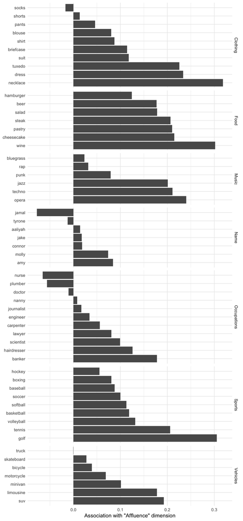

```r
# Create a basic scatter plot
ggplot(scores_df, aes(x = score, y = reorder(word, desc(score)))) +
  geom_col(color = NA) +
  facet_grid(rows = vars(category), scales = "free_y", space = "free") +
  labs(x = "Association with \"Affluence\" dimension", y = NULL) +
  theme_minimal()
```

### Replicate their Figure 3

```r
words <- c("jazz", "rap", "opera", "punk", "techno", "hip_hop", "bluegrass")

associations <- list()
# Race associations (see Kozlowski et al., 2019, Figure 3)
for (dim_name in c("Affluence", "Race")) {
  associations[[dim_name]] <- list()
  for (w in words) {
    if (w %in% rownames(wv)) {
      v <- normalize_vector(wv[w, ])
      cs <- cosine_similarity(v, dims_normalized[[dim_name]])
      associations[[dim_name]][[w]] <- cs
    }
  }
}
```

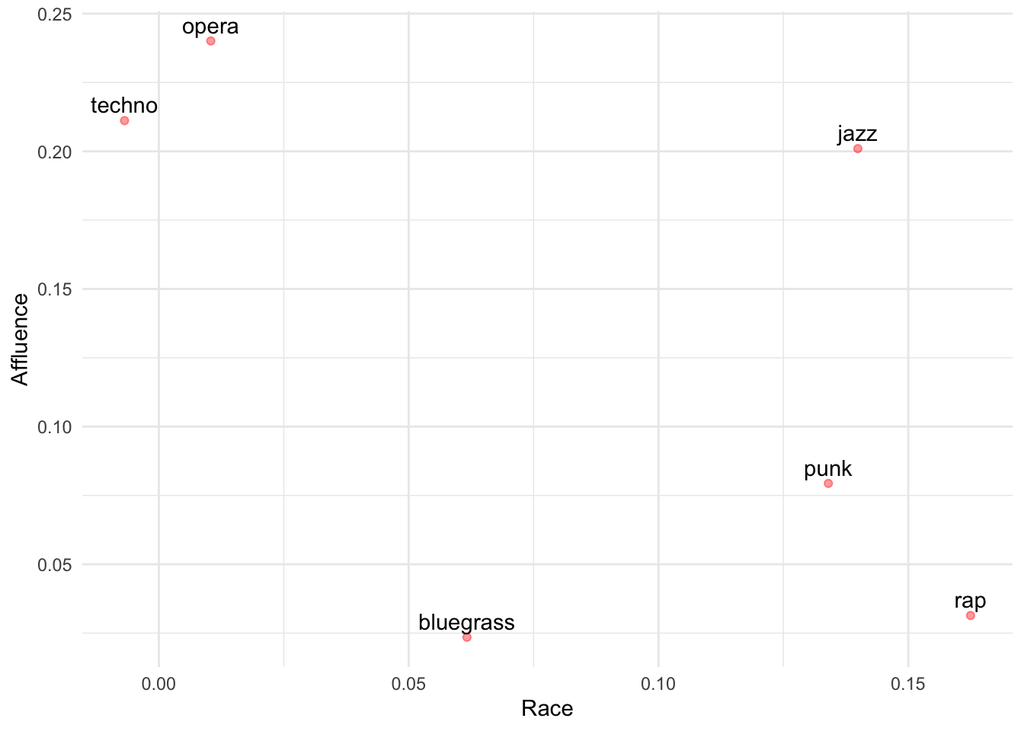

```r
# Convert to data frame for plotting
plot_data <- data.frame(
  word = names(associations[["Affluence"]]),
  Race = unlist(associations[["Race"]]),
  Affluence = unlist(associations[["Affluence"]])
)

# Create scatterplot
ggplot(plot_data, aes(x = Race, y = Affluence)) +
  geom_point(color = "red", alpha = 0.4) +
  geom_text(aes(label = word), vjust = -0.5, hjust = 0.5) +
  labs(x = "Race", y = "Affluence") +
  theme_minimal()
```

### Replicate their Figure 5

```r
# Compute similarities between all dimension pairs
dim_names <- names(dims_normalized)
dim_sims <- matrix(NA, nrow = length(dim_names), ncol = length(dim_names))
rownames(dim_sims) <- dim_names
colnames(dim_sims) <- dim_names

for (i in 1:length(dim_names)) {
  for (j in 1:length(dim_names)) {
    if (i != j) {
      dim_sims[i, j] <- cosine_similarity(
        dims_normalized[[dim_names[i]]],
        dims_normalized[[dim_names[j]]]
      )
    }
  }
}
```

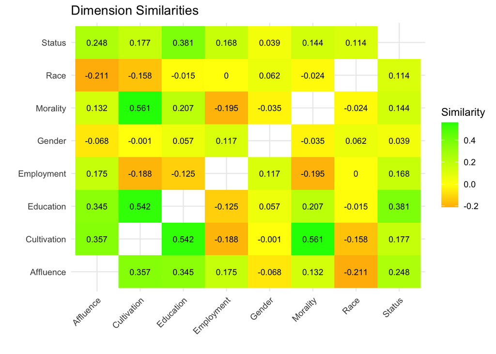

```r
# Convert matrix to long format for ggplot
dim_sims_df <- data.frame(
  Dimension1 = rep(rownames(dim_sims), times = ncol(dim_sims)),
  Dimension2 = rep(colnames(dim_sims), each = nrow(dim_sims)),
  Similarity = as.numeric(dim_sims)
)
dim_sims_df <- filter(dim_sims_df, !is.na(Similarity))
# melt(dim_sims, na.rm = TRUE)
# names(dim_sims_df) <- c("Dimension1", "Dimension2", "Similarity")

# Create heatmap
ggplot(dim_sims_df, aes(x = Dimension2, y = Dimension1, fill = Similarity)) +
  geom_tile() +
  geom_text(aes(label = round(Similarity, 3)), color = "black", size = 3) +
  scale_fill_gradient2(low = "red", high = "green", mid = "yellow", midpoint = 0) +
  labs(title = "Dimension Similarities", x = "", y = "", fill = "Similarity") +
  theme_minimal() +
  theme(axis.text.x = element_text(angle = 45, hjust = 1))
```

*Note:* Kozlowski *et al.* (2019) report the following similarities of other dimensions with the **Affluence** (class) dimension in Figure 5 for the period 1990:

- Cultivation: 0.31
- Education: 0.42
- Employment: 0.08
- Gender: -.05
- Morality: 0.1
- Status: 0.23